# lista_2

atividade: Lista 2  
prazo: 01/06/2026  
aluno: Rafael Leal Machado

> Setup

```python
import numpy as np
import pandas as pd
import matplotlib.pyplot as plt
%matplotlib inline
```

> Implementacao dos metodos Simplex *from scratch* (sem solver nos passos intermediarios). Convencao: maximizacao; custo reduzido $r_j = z_j - c_j$; otimo se todo $r_j \ge 0$; entra o mais negativo; ilimitado se a coluna/direcao entrante $\le 0$; multiplas se alguma nao-basica tem $r_j=0$; infactivel se a Fase 1 nao zera as artificiais.

**Nucleos contados + forma padrao**

```python
from dataclasses import dataclass, field
from typing import List, Optional, Sequence

import numpy as np

TOL = 1e-9


@dataclass
class OpCounter:
    """Contabiliza operações elementares executadas pelos núcleos numéricos."""

    add: int = 0
    sub: int = 0
    mul: int = 0
    div: int = 0

    def total(self) -> int:
        return self.add + self.sub + self.mul + self.div

    def as_dict(self) -> dict:
        return {
            "soma": self.add,
            "subtracao": self.sub,
            "multiplicacao": self.mul,
            "divisao": self.div,
            "total": self.total(),
        }

    def snapshot(self) -> "OpCounter":
        return OpCounter(self.add, self.sub, self.mul, self.div)

    def __sub__(self, other: "OpCounter") -> "OpCounter":
        return OpCounter(
            self.add - other.add,
            self.sub - other.sub,
            self.mul - other.mul,
            self.div - other.div,
        )


def _bump(counter: Optional[OpCounter], *, add=0, sub=0, mul=0, div=0) -> None:
    if counter is not None:
        counter.add += add
        counter.sub += sub
        counter.mul += mul
        counter.div += div


def k_dot(u: np.ndarray, v: np.ndarray, counter: Optional[OpCounter] = None) -> float:
    """Produto interno u·v de vetores de tamanho m: m mult + (m-1) somas."""
    m = len(u)
    _bump(counter, mul=m, add=max(m - 1, 0))
    return float(np.dot(u, v))


def k_matvec(M: np.ndarray, v: np.ndarray, counter: Optional[OpCounter] = None) -> np.ndarray:
    """Produto matriz-vetor M(p×q)·v: p·q mult + p·(q-1) somas."""
    p, q = M.shape
    _bump(counter, mul=p * q, add=p * max(q - 1, 0))
    return M @ v


def k_vecmat(v: np.ndarray, M: np.ndarray, counter: Optional[OpCounter] = None) -> np.ndarray:
    """Produto vetor-matriz v·M(p×q): q·p mult + q·(p-1) somas (ex.: y = c_B B^{-1})."""
    p, q = M.shape
    _bump(counter, mul=q * p, add=q * max(p - 1, 0))
    return v @ M


def k_pivot(T: np.ndarray, r: int, q: int, counter: Optional[OpCounter] = None) -> None:
    """
    Pivoteamento de Gauss-Jordan no quadro ``T`` (in-place) sobre o elemento (r, q).

    A linha-pivô é normalizada (divisões) e a coluna ``q`` é zerada em todas as
    demais linhas (mult + subtração por elemento). Conta exatamente as operações
    densas executadas.
    """
    rows, cols = T.shape
    p = T[r, q]
    # Normaliza a linha-pivô: divide as (cols-1) entradas != coluna-pivô.
    for k in range(cols):
        if k == q:
            continue
        T[r, k] = T[r, k] / p
        _bump(counter, div=1)
    T[r, q] = 1.0
    # Elimina a coluna q das demais linhas (mult + sub por entrada != coluna-pivô).
    for i in range(rows):
        if i == r:
            continue
        factor = T[i, q]
        for k in range(cols):
            if k == q:
                continue
            T[i, k] = T[i, k] - factor * T[r, k]
            _bump(counter, mul=1, sub=1)
        T[i, q] = 0.0


def k_eta_update(Binv: np.ndarray, d: np.ndarray, r: int,
                 counter: Optional[OpCounter] = None) -> None:
    """
    Atualiza B^{-1} (in-place) por produto elementar (matriz eta) quando a r-ésima
    variável básica sai e entra a variável cuja direção simplex é ``d = B^{-1} A_q``.

    Equivale a pivotar as linhas de B^{-1} usando ``d`` como coluna-pivô:
        nova_linha_r = linha_r / d_r
        nova_linha_i = linha_i - d_i * nova_linha_r      (i != r)
    """
    m = Binv.shape[0]
    dr = d[r]
    for k in range(m):
        Binv[r, k] = Binv[r, k] / dr
        _bump(counter, div=1)
    for i in range(m):
        if i == r:
            continue
        di = d[i]
        for k in range(m):
            Binv[i, k] = Binv[i, k] - di * Binv[r, k]
            _bump(counter, mul=1, sub=1)


@dataclass
class StandardForm:
    A: np.ndarray                # m x N (colunas estruturais + folga/excesso/artificiais)
    b: np.ndarray                # m (>= 0)
    c: np.ndarray                # N — custos da FASE 2 (já em forma de maximização)
    var_names: List[str]         # N nomes de colunas
    basis: List[int]             # m índices de colunas da base inicial
    artificial_idx: List[int]    # índices das colunas artificiais
    is_artificial: List[bool]    # máscara por coluna
    n_structural: int            # número de variáveis de decisão originais
    structural_names: List[str]
    original_sense: str          # 'max' ou 'min'
    obj_sign: int                # +1 (max) ou -1 (min): obj_reportado = obj_sign * obj_max
    senses_norm: List[str]       # sentidos após normalização b >= 0

    @property
    def m(self) -> int:
        return self.A.shape[0]

    @property
    def N(self) -> int:
        return self.A.shape[1]

    @property
    def enterable(self) -> List[bool]:
        """Colunas que PODEM entrar na base (todas, exceto artificiais)."""
        return [not a for a in self.is_artificial]


def to_standard_form(c: Sequence[float], A: Sequence[Sequence[float]],
                     senses: Sequence[str], b: Sequence[float],
                     sense: str = "max",
                     var_names: Optional[Sequence[str]] = None) -> StandardForm:
    """
    Converte (c, A, senses, b, sense) para a forma padrão de igualdades com base
    inicial identidade (folgas para <=, artificiais para >= e =).

    Args:
        c: coeficientes da função objetivo (tamanho n).
        A: matriz de restrições (m x n).
        senses: lista de '<=', '>=' ou '=' (tamanho m).
        b: lado direito (tamanho m).
        sense: 'max' ou 'min'.
        var_names: nomes das variáveis estruturais.

    Returns:
        StandardForm pronto para os solvers de duas fases.
    """
    A = np.array(A, dtype=float)
    b = np.array(b, dtype=float)
    c = np.array(c, dtype=float)
    m, n = A.shape
    if var_names is None:
        var_names = [f"x{j + 1}" for j in range(n)]
    var_names = list(var_names)
    senses = list(senses)

    sense = sense.lower()
    if sense == "min":
        c_max = -c.copy()
        obj_sign = -1
    else:
        c_max = c.copy()
        obj_sign = 1

    A = A.copy()
    b = b.copy()
    # Normaliza b >= 0 (multiplica a linha por -1 e inverte o sentido se b < 0).
    for i in range(m):
        if b[i] < 0:
            A[i, :] *= -1.0
            b[i] *= -1.0
            if senses[i] == "<=":
                senses[i] = ">="
            elif senses[i] == ">=":
                senses[i] = "<="

    cols: List[np.ndarray] = [A[:, j].copy() for j in range(n)]
    names: List[str] = list(var_names)
    cost: List[float] = list(c_max)
    is_art: List[bool] = [False] * n
    basis: List[Optional[int]] = [None] * m
    artificial_idx: List[int] = []

    def add_col(vec: np.ndarray, name: str, cst: float, art: bool) -> int:
        cols.append(vec)
        names.append(name)
        cost.append(cst)
        is_art.append(art)
        return len(cols) - 1

    for i in range(m):
        s = senses[i]
        if s == "<=":
            e = np.zeros(m)
            e[i] = 1.0
            idx = add_col(e, f"s{i + 1}", 0.0, False)   # folga
            basis[i] = idx
        elif s == ">=":
            e = np.zeros(m)
            e[i] = -1.0
            add_col(e, f"e{i + 1}", 0.0, False)         # excesso (surplus)
            a = np.zeros(m)
            a[i] = 1.0
            idx = add_col(a, f"a{i + 1}", 0.0, True)    # artificial
            basis[i] = idx
            artificial_idx.append(idx)
        else:  # '='
            a = np.zeros(m)
            a[i] = 1.0
            idx = add_col(a, f"a{i + 1}", 0.0, True)
            basis[i] = idx
            artificial_idx.append(idx)

    A_std = np.column_stack(cols)
    return StandardForm(
        A=A_std,
        b=b,
        c=np.array(cost, dtype=float),
        var_names=names,
        basis=[int(x) for x in basis],
        artificial_idx=artificial_idx,
        is_artificial=is_art,
        n_structural=n,
        structural_names=var_names,
        original_sense=sense,
        obj_sign=obj_sign,
        senses_norm=senses,
    )


def clean(x: float, tol: float = 1e-9) -> float:
    """Arredonda ruído numérico para zero/inteiro próximo (apenas para exibição)."""
    if abs(x) < tol:
        return 0.0
    r = round(x)
    if abs(x - r) < 1e-7:
        return float(r)
    return float(x)


def df_to_markdown(df, floatfmt: str = "{:.3g}") -> str:
    """Converte um DataFrame em tabela markdown (sem depender de 'tabulate')."""
    cols = list(df.columns)
    header = "| " + " | ".join([str(df.index.name or "")] + [str(c) for c in cols]) + " |"
    sep = "| " + " | ".join(["---"] * (len(cols) + 1)) + " |"
    lines = [header, sep]
    for idx, row in df.iterrows():
        cells = []
        for c in cols:
            v = row[c]
            if isinstance(v, (int, float, np.floating, np.integer)):
                cells.append(floatfmt.format(float(v)))
            else:
                cells.append(str(v))
        lines.append("| " + " | ".join([str(idx)] + cells) + " |")
    return "\n".join(lines)


def fmt_num(x: float, width: int = 9, prec: int = 3) -> str:
    """Formata número para alinhamento em quadros de console."""
    x = clean(x)
    if x == int(x) and abs(x) < 1e6:
        s = f"{int(x)}"
    else:
        s = f"{x:.{prec}f}"
    return s.rjust(width)
```

**Simplex por Quadros**

```python
from dataclasses import dataclass, field
from typing import Dict, List, Optional

import numpy as np
import pandas as pd



@dataclass
class TableauResult:
    status: str                       # 'optimal' | 'unbounded' | 'infeasible'
    objective: Optional[float]        # valor ótimo (sentido original) ou None
    x: Dict[str, float]               # variáveis estruturais -> valor
    multiple_optima: bool = False
    multiple_var: Optional[str] = None
    alt_vertex: Optional[Dict[str, float]] = None
    iterations: List[dict] = field(default_factory=list)
    n_iterations: int = 0
    counter: Optional[OpCounter] = None
    basis_final: List[str] = field(default_factory=list)
    reduced_final: Dict[str, float] = field(default_factory=dict)
    sf: Optional[StandardForm] = None
    entering_unbounded: Optional[str] = None
    phase1_value: Optional[float] = None

    @property
    def solution_type(self) -> str:
        if self.status == "unbounded":
            return "ILIMITADA"
        if self.status == "infeasible":
            return "INFACTÍVEL"
        if self.multiple_optima:
            return "MÚLTIPLAS ÓTIMAS"
        return "ÓTIMA ÚNICA"


def _set_obj_row(T: np.ndarray, basis: List[int], cost: np.ndarray,
                 m: int, N: int) -> None:
    """Recalcula a linha-objetivo r_j = z_j - c_j e Z = c_B·b (setup, não contado)."""
    cB = np.array([cost[b] for b in basis])
    for j in range(N):
        zj = float(np.dot(cB, T[:m, j]))
        T[m, j] = zj - cost[j]
    T[m, N] = float(np.dot(cB, T[:m, N]))


def _snapshot(T: np.ndarray, basis: List[int], sf: StandardForm,
              phase: int, it: int) -> dict:
    m, N = sf.m, sf.N
    index = [sf.var_names[b] for b in basis] + ["Zj - Cj"]
    data = np.vstack([T[:m, :], T[m:m + 1, :]])
    df = pd.DataFrame(
        [[clean(v) for v in data[r, :]] for r in range(m + 1)],
        index=index,
        columns=sf.var_names + ["b"],
    )
    df.index.name = "Base"
    reduced = {sf.var_names[j]: clean(T[m, j]) for j in range(N)}
    return {
        "phase": phase,
        "iter": it,
        "basis": [sf.var_names[b] for b in basis],
        "tableau": df,
        "tableau_raw": T.copy(),
        "reduced": reduced,
        "obj_max": clean(T[m, N]),
        "entering": None,
        "leaving": None,
        "ratios": [],
        "pivot_rc": None,
        "pivot_elem": None,
        "note": "",
        "ops_iter": None,
    }


def _format_ratios(T: np.ndarray, basis: List[int], sf: StandardForm,
                   q: int, m: int, N: int) -> List[dict]:
    out = []
    for i in range(m):
        aiq = T[i, q]
        entry = {
            "base": sf.var_names[basis[i]],
            "b": clean(T[i, N]),
            "col": clean(aiq),
            "ratio": None,
        }
        if aiq > TOL:
            entry["ratio"] = clean(T[i, N] / aiq)
        out.append(entry)
    return out


def _loop(T: np.ndarray, basis: List[int], cost: np.ndarray, sf: StandardForm,
          phase: int, logs: List[dict], counter: Optional[OpCounter],
          max_iter: int) -> str:
    m, N = sf.m, sf.N
    enterable = sf.enterable
    for it in range(max_iter):
        c0 = counter.snapshot() if counter is not None else None
        rec = _snapshot(T, basis, sf, phase, it)
        basic_set = set(basis)

        # Critério de entrada: r_j mais negativo entre não-básicas elegíveis.
        q = None
        best = -TOL
        for j in range(N):
            if not enterable[j] or j in basic_set:
                continue
            if T[m, j] < best:
                best = T[m, j]
                q = j

        if q is None:
            rec["note"] = f"Fase {phase}: ótimo (todos r_j >= 0)."
            rec["ops_iter"] = (counter - c0).as_dict() if counter is not None else None
            logs.append(rec)
            return "optimal"

        rec["entering"] = sf.var_names[q]
        rec["pivot_rc"] = clean(T[m, q])
        rec["ratios"] = _format_ratios(T, basis, sf, q, m, N)

        # Teste da razão mínima.
        leave_r = None
        min_ratio = None
        for i in range(m):
            aiq = T[i, q]
            if aiq > TOL:
                ratio = T[i, N] / aiq
                if counter is not None:
                    counter.div += 1
                if min_ratio is None or ratio < min_ratio - TOL:
                    min_ratio = ratio
                    leave_r = i

        if leave_r is None:
            rec["note"] = (f"Coluna de {sf.var_names[q]} tem todos a_iq <= 0 "
                           f"=> PRIMAL ILIMITADO.")
            rec["ops_iter"] = (counter - c0).as_dict() if counter is not None else None
            logs.append(rec)
            return "unbounded"

        rec["leaving"] = sf.var_names[basis[leave_r]]
        rec["pivot_elem"] = clean(T[leave_r, q])
        rec["note"] = (f"Entra {sf.var_names[q]} (r={rec['pivot_rc']}), "
                       f"sai {rec['leaving']} (razão mín = {clean(min_ratio)}).")
        logs.append(rec)

        k_pivot(T, leave_r, q, counter)
        basis[leave_r] = q
        if counter is not None:
            rec["ops_iter"] = (counter - c0).as_dict()

    raise RuntimeError("Número máximo de iterações excedido (possível ciclagem).")


def _drive_out_artificials(T: np.ndarray, basis: List[int], sf: StandardForm,
                           counter: Optional[OpCounter], logs: List[dict]) -> None:
    """Remove artificiais que permaneceram básicas em nível zero após a Fase 1."""
    m, N = sf.m, sf.N
    art = set(sf.artificial_idx)
    for r in range(m):
        if basis[r] in art and abs(T[r, N]) < 1e-7:
            # Procura coluna não-artificial não-básica com pivô != 0 nesta linha.
            for j in range(N):
                if sf.is_artificial[j] or j in basis:
                    continue
                if abs(T[r, j]) > TOL:
                    k_pivot(T, r, j, counter)
                    basis[r] = j
                    break


def solve_tableau(c, A, senses, b, sense: str = "max",
                  var_names: Optional[List[str]] = None,
                  count_ops: bool = False, max_iter: int = 200) -> TableauResult:
    """
    Resolve o PL pelo Simplex por Quadros (duas fases).

    Args:
        c, A, senses, b: dados do PL (senses em '<=', '>=', '=').
        sense: 'max' ou 'min'.
        var_names: nomes das variáveis estruturais.
        count_ops: se True, contabiliza operações aritméticas dos pivôs.

    Returns:
        TableauResult com status, solução, tipo e log de iterações.
    """
    sf = to_standard_form(c, A, senses, b, sense, var_names)
    m, N = sf.m, sf.N
    counter = OpCounter() if count_ops else None
    logs: List[dict] = []

    T = np.zeros((m + 1, N + 1))
    T[:m, :N] = sf.A
    T[:m, N] = sf.b
    basis = list(sf.basis)

    # ----- FASE 1 (se houver artificiais) -----
    phase1_value = None
    if sf.artificial_idx:
        phase1_cost = np.zeros(N)
        for idx in sf.artificial_idx:
            phase1_cost[idx] = -1.0   # maximiza -(soma das artificiais)
        _set_obj_row(T, basis, phase1_cost, m, N)
        _loop(T, basis, phase1_cost, sf, 1, logs, counter, max_iter)
        phase1_value = clean(T[m, N])           # = -(soma das artificiais)
        if T[m, N] < -1e-7:
            return TableauResult(
                status="infeasible", objective=None, x={},
                iterations=logs, n_iterations=len(logs), counter=counter,
                sf=sf, phase1_value=phase1_value,
            )
        _drive_out_artificials(T, basis, sf, counter, logs)

    # ----- FASE 2 -----
    _set_obj_row(T, basis, sf.c, m, N)
    status = _loop(T, basis, sf.c, sf, 2, logs, counter, max_iter)

    n_iter = sum(1 for L in logs if L["entering"] is not None)

    if status == "unbounded":
        last = logs[-1]
        return TableauResult(
            status="unbounded", objective=None, x={},
            iterations=logs, n_iterations=n_iter, counter=counter, sf=sf,
            entering_unbounded=last["entering"], phase1_value=phase1_value,
        )

    # ----- Ótimo: extrai solução -----
    x_full = np.zeros(N)
    for i in range(m):
        x_full[basis[i]] = T[i, N]
    x = {sf.structural_names[j]: clean(x_full[j]) for j in range(sf.n_structural)}
    obj = sf.obj_sign * T[m, N]
    reduced_final = {sf.var_names[j]: clean(T[m, j]) for j in range(N)}

    # ----- Detecção de múltiplas ótimas -----
    basic_set = set(basis)
    multiple = False
    mult_var = None
    alt_vertex = None
    for j in range(N):
        if sf.enterable[j] and j not in basic_set and abs(T[m, j]) < 1e-7:
            multiple = True
            mult_var = sf.var_names[j]
            # Tenta produzir um segundo vértice ótimo pivotando x_j para dentro.
            leave_r, min_ratio = None, None
            for i in range(m):
                if T[i, j] > TOL:
                    ratio = T[i, N] / T[i, j]
                    if min_ratio is None or ratio < min_ratio - TOL:
                        min_ratio, leave_r = ratio, i
            if leave_r is not None:
                T2 = T.copy()
                basis2 = list(basis)
                k_pivot(T2, leave_r, j, None)
                basis2[leave_r] = j
                xf2 = np.zeros(N)
                for i in range(m):
                    xf2[basis2[i]] = T2[i, N]
                alt_vertex = {sf.structural_names[k]: clean(xf2[k])
                              for k in range(sf.n_structural)}
            break

    return TableauResult(
        status="optimal", objective=clean(obj), x=x,
        multiple_optima=multiple, multiple_var=mult_var, alt_vertex=alt_vertex,
        iterations=logs, n_iterations=n_iter, counter=counter,
        basis_final=[sf.var_names[b] for b in basis],
        reduced_final=reduced_final, sf=sf, phase1_value=phase1_value,
    )


def print_tableau_result(res: TableauResult, title: str = "") -> None:
    """Imprime, formatado, todos os quadros de cada iteração e o desfecho."""
    line = "=" * 78
    if title:
        print(line)
        print(f"  SIMPLEX POR QUADROS — {title}")
        print(line)

    for L in res.iterations:
        tag = f"FASE {L['phase']} · Iteração {L['iter']}"
        print(f"\n--- {tag} ---")
        print(f"Base: {{{', '.join(L['basis'])}}}    Z(max) = {L['obj_max']}")
        print(L["tableau"].to_string(float_format=lambda v: fmt_num(v).strip()))
        if L["entering"]:
            print(f"  -> Entra: {L['entering']}  (r = {L['pivot_rc']})")
            if L["ratios"]:
                rs = []
                for rr in L["ratios"]:
                    r_txt = "—" if rr["ratio"] is None else f"{rr['ratio']:.3g}"
                    rs.append(f"{rr['base']}: {rr['b']:.3g}/{rr['col']:.3g}={r_txt}")
                print("  Razões: " + " | ".join(rs))
        if L["leaving"]:
            print(f"  -> Sai:   {L['leaving']}  (pivô = {L['pivot_elem']})")
        if L["note"]:
            print(f"  {L['note']}")

    print(f"\n{'-' * 40}\nDESFECHO: {res.solution_type}")
    if res.status == "optimal":
        print(f"  Z* = {res.objective}")
        print(f"  x* = {res.x}")
        print(f"  Base ótima: {{{', '.join(res.basis_final)}}}")
        if res.multiple_optima:
            print(f"  Múltiplas ótimas: r_{res.multiple_var} = 0 (não-básica).")
            if res.alt_vertex:
                print(f"  Vértice ótimo alternativo: {res.alt_vertex}")
    elif res.status == "unbounded":
        print(f"  Direção ilimitada via entrada de {res.entering_unbounded}.")
    elif res.status == "infeasible":
        print(f"  Fase 1 terminou com soma de artificiais = "
              f"{-(res.phase1_value or 0):.4g} > 0 (região factível vazia).")
```

**Simplex Revisado** ($B^{-1}$ por matriz eta)

```python
from dataclasses import dataclass, field
from typing import Dict, List, Optional

import numpy as np
import pandas as pd



@dataclass
class RevisedResult:
    status: str
    objective: Optional[float]
    x: Dict[str, float]
    multiple_optima: bool = False
    multiple_var: Optional[str] = None
    alt_vertex: Optional[Dict[str, float]] = None
    iterations: List[dict] = field(default_factory=list)
    n_iterations: int = 0
    counter: Optional[OpCounter] = None
    basis_final: List[str] = field(default_factory=list)
    reduced_final: Dict[str, float] = field(default_factory=dict)
    sf: Optional[StandardForm] = None
    entering_unbounded: Optional[str] = None
    phase1_value: Optional[float] = None

    @property
    def solution_type(self) -> str:
        if self.status == "unbounded":
            return "ILIMITADA"
        if self.status == "infeasible":
            return "INFACTÍVEL"
        if self.multiple_optima:
            return "MÚLTIPLAS ÓTIMAS"
        return "ÓTIMA ÚNICA"


def _basis_names(basis: List[int], sf: StandardForm) -> List[str]:
    return [sf.var_names[b] for b in basis]


def _alt_vertex_revised(A_std, b, basis, Binv, q, sf) -> Optional[Dict[str, float]]:
    """Calcula um segundo vértice ótimo pivotando x_q (custo reduzido nulo) p/ dentro."""
    m = sf.m
    d = Binv @ A_std[:, q]
    xB = Binv @ b
    leave_r, min_ratio = None, None
    for i in range(m):
        if d[i] > TOL:
            ratio = xB[i] / d[i]
            if min_ratio is None or ratio < min_ratio - TOL:
                min_ratio, leave_r = ratio, i
    if leave_r is None:
        return None
    Binv2 = Binv.copy()
    k_eta_update(Binv2, d, leave_r, None)
    basis2 = list(basis)
    basis2[leave_r] = q
    xB2 = Binv2 @ b
    xf = np.zeros(sf.N)
    for i in range(m):
        xf[basis2[i]] = xB2[i]
    return {sf.structural_names[k]: clean(xf[k]) for k in range(sf.n_structural)}


def _rev_loop(A_std, b, cost, basis, Binv, sf, phase, logs, counter, max_iter) -> str:
    m, N = sf.m, sf.N
    enterable = sf.enterable
    for it in range(max_iter):
        c0 = counter.snapshot() if counter is not None else None
        cB = np.array([cost[bi] for bi in basis])
        xB = k_matvec(Binv, b, counter)          # B^{-1} b
        y = k_vecmat(cB, Binv, counter)          # c_B B^{-1}  (multiplicadores)

        basic_set = set(basis)
        reduced: Dict[str, float] = {}
        q, best = None, -TOL
        for j in range(N):
            if j in basic_set or not enterable[j]:
                continue
            zj = k_dot(y, A_std[:, j], counter)
            rj = zj - cost[j]
            if counter is not None:
                counter.sub += 1
            reduced[sf.var_names[j]] = clean(rj)
            if rj < best:
                best, q = rj, j

        rec = {
            "phase": phase, "iter": it,
            "basis": _basis_names(basis, sf),
            "Binv": pd.DataFrame(
                [[clean(v) for v in Binv[r]] for r in range(m)],
                index=_basis_names(basis, sf),
                columns=[f"e{c+1}" for c in range(m)]),
            "cB": {sf.var_names[basis[i]]: clean(cB[i]) for i in range(m)},
            "y": [clean(v) for v in y],
            "xB": {sf.var_names[basis[i]]: clean(xB[i]) for i in range(m)},
            "reduced": reduced,
            "entering": None, "direction": None, "ratios": [],
            "leaving": None, "pivot_rc": None, "note": "", "ops_iter": None,
        }

        if q is None:
            rec["note"] = f"Fase {phase}: ótimo (todos r_j >= 0)."
            rec["ops_iter"] = (counter - c0).as_dict() if counter is not None else None
            logs.append(rec)
            return "optimal"

        d = k_matvec(Binv, A_std[:, q], counter)  # direção simplex
        rec["entering"] = sf.var_names[q]
        rec["pivot_rc"] = clean(best)
        rec["direction"] = {sf.var_names[basis[i]]: clean(d[i]) for i in range(m)}

        leave_r, min_ratio = None, None
        ratios = []
        for i in range(m):
            if d[i] > TOL:
                ratio = xB[i] / d[i]
                if counter is not None:
                    counter.div += 1
                ratios.append({"base": sf.var_names[basis[i]],
                               "xB": clean(xB[i]), "d": clean(d[i]),
                               "ratio": clean(ratio)})
                if min_ratio is None or ratio < min_ratio - TOL:
                    min_ratio, leave_r = ratio, i
            else:
                ratios.append({"base": sf.var_names[basis[i]],
                               "xB": clean(xB[i]), "d": clean(d[i]), "ratio": None})
        rec["ratios"] = ratios

        if leave_r is None:
            rec["note"] = (f"Direção d = B^-1 A_{sf.var_names[q]} <= 0 "
                           f"=> PRIMAL ILIMITADO.")
            rec["ops_iter"] = (counter - c0).as_dict() if counter is not None else None
            logs.append(rec)
            return "unbounded"

        rec["leaving"] = sf.var_names[basis[leave_r]]
        rec["note"] = (f"Entra {sf.var_names[q]} (r={rec['pivot_rc']}), "
                       f"sai {rec['leaving']} (razão mín = {clean(min_ratio)}).")
        logs.append(rec)

        k_eta_update(Binv, d, leave_r, counter)
        basis[leave_r] = q
        if counter is not None:
            rec["ops_iter"] = (counter - c0).as_dict()

    raise RuntimeError("Número máximo de iterações excedido (possível ciclagem).")


def _drive_out_artificials_rev(A_std, b, basis, Binv, sf, counter) -> None:
    m, N = sf.m, sf.N
    art = set(sf.artificial_idx)
    xB = Binv @ b
    for r in range(m):
        if basis[r] in art and abs(xB[r]) < 1e-7:
            for j in range(N):
                if sf.is_artificial[j] or j in basis:
                    continue
                dj = Binv @ A_std[:, j]
                if abs(dj[r]) > TOL:
                    k_eta_update(Binv, dj, r, counter)
                    basis[r] = j
                    break


def solve_revised(c, A, senses, b, sense: str = "max",
                  var_names: Optional[List[str]] = None,
                  count_ops: bool = False, max_iter: int = 200) -> RevisedResult:
    """Resolve o PL pelo Simplex Revisado (duas fases, B^{-1} explícita)."""
    sf = to_standard_form(c, A, senses, b, sense, var_names)
    m, N = sf.m, sf.N
    counter = OpCounter() if count_ops else None
    logs: List[dict] = []

    A_std = sf.A
    bvec = sf.b
    basis = list(sf.basis)
    Binv = np.eye(m)

    phase1_value = None
    if sf.artificial_idx:
        cost1 = np.zeros(N)
        for idx in sf.artificial_idx:
            cost1[idx] = -1.0
        _rev_loop(A_std, bvec, cost1, basis, Binv, sf, 1, logs, counter, max_iter)
        cB = np.array([cost1[bi] for bi in basis])
        w = float(np.dot(cB, Binv @ bvec))
        phase1_value = clean(w)
        if w < -1e-7:
            return RevisedResult(
                status="infeasible", objective=None, x={},
                iterations=logs, n_iterations=len(logs), counter=counter,
                sf=sf, phase1_value=phase1_value)
        _drive_out_artificials_rev(A_std, bvec, basis, Binv, sf, counter)

    status = _rev_loop(A_std, bvec, sf.c, basis, Binv, sf, 2, logs, counter, max_iter)
    n_iter = sum(1 for L in logs if L["entering"] is not None)

    if status == "unbounded":
        return RevisedResult(
            status="unbounded", objective=None, x={},
            iterations=logs, n_iterations=n_iter, counter=counter, sf=sf,
            entering_unbounded=logs[-1]["entering"], phase1_value=phase1_value)

    xB = Binv @ bvec
    x_full = np.zeros(N)
    for i in range(m):
        x_full[basis[i]] = xB[i]
    x = {sf.structural_names[j]: clean(x_full[j]) for j in range(sf.n_structural)}
    cB = np.array([sf.c[bi] for bi in basis])
    obj = sf.obj_sign * float(np.dot(cB, xB))

    # custos reduzidos finais (todas as não-básicas elegíveis)
    y = cB @ Binv
    reduced_final = {}
    basic_set = set(basis)
    multiple, mult_var, alt_vertex = False, None, None
    for j in range(N):
        if j in basic_set or not sf.enterable[j]:
            continue
        rj = float(np.dot(y, A_std[:, j])) - sf.c[j]
        reduced_final[sf.var_names[j]] = clean(rj)
        if abs(rj) < 1e-7 and not multiple:
            multiple, mult_var = True, sf.var_names[j]
            alt_vertex = _alt_vertex_revised(A_std, bvec, basis, Binv, j, sf)

    return RevisedResult(
        status="optimal", objective=clean(obj), x=x,
        multiple_optima=multiple, multiple_var=mult_var, alt_vertex=alt_vertex,
        iterations=logs, n_iterations=n_iter, counter=counter,
        basis_final=_basis_names(basis, sf), reduced_final=reduced_final,
        sf=sf, phase1_value=phase1_value)


def print_revised_result(res: RevisedResult, title: str = "") -> None:
    line = "=" * 78
    if title:
        print(line)
        print(f"  SIMPLEX REVISADO — {title}")
        print(line)

    for L in res.iterations:
        print(f"\n--- FASE {L['phase']} · Iteração {L['iter']} ---")
        print(f"Base: {{{', '.join(L['basis'])}}}")
        print("B^-1 =")
        print(L["Binv"].to_string(float_format=lambda v: f"{v:.4g}"))
        print(f"  c_B = {L['cB']}")
        print(f"  y = c_B B^-1 = {[round(v, 4) for v in L['y']]}")
        print(f"  x_B = B^-1 b = {L['xB']}")
        print(f"  custos reduzidos r_j = z_j - c_j (não-básicas): {L['reduced']}")
        if L["entering"]:
            print(f"  -> Entra: {L['entering']} (r = {L['pivot_rc']}, mais negativo)")
            print(f"  direção d = B^-1 A_{L['entering']} = {L['direction']}")
            rs = []
            for rr in L["ratios"]:
                r_txt = "—" if rr["ratio"] is None else f"{rr['ratio']:.3g}"
                rs.append(f"{rr['base']}: {rr['xB']:.3g}/{rr['d']:.3g}={r_txt}")
            print("  Razões (d_i>0): " + " | ".join(rs))
        if L["leaving"]:
            print(f"  -> Sai: {L['leaving']}")
        if L["note"]:
            print(f"  {L['note']}")

    print(f"\n{'-' * 40}\nDESFECHO: {res.solution_type}")
    if res.status == "optimal":
        print(f"  Z* = {res.objective}")
        print(f"  x* = {res.x}")
        print(f"  Base ótima: {{{', '.join(res.basis_final)}}}")
        if res.multiple_optima:
            print(f"  Múltiplas ótimas: r_{res.multiple_var} = 0 (não-básica).")
            if res.alt_vertex:
                print(f"  Vértice alternativo: {res.alt_vertex}")
    elif res.status == "unbounded":
        print(f"  Direção ilimitada via entrada de {res.entering_unbounded}.")
    elif res.status == "infeasible":
        print(f"  Fase 1 terminou com soma de artificiais = "
              f"{-(res.phase1_value or 0):.4g} > 0 (região factível vazia).")
```

**Verificacao final com Gurobi** (apenas confere a solucao)

```python
from typing import Dict, List, Optional, Sequence

import gurobipy as gp
from gurobipy import GRB


def verify_lp(c: Sequence[float], A: Sequence[Sequence[float]],
              senses: Sequence[str], b: Sequence[float],
              sense: str = "max", var_names: Optional[List[str]] = None,
              save_lp: Optional[str] = None) -> Dict:
    """
    Resolve o PL com o Gurobi e devolve status/objetivo/solução.

    Args:
        c, A, senses, b: dados do PL (senses em '<=', '>=', '=').
        sense: 'max' ou 'min'.
        var_names: nomes das variáveis estruturais.
        save_lp: se fornecido, grava o modelo em formato .lp nesse caminho.

    Returns:
        dict com chaves: status ('optimal'|'unbounded'|'infeasible'),
        objective (ou None), x (dict ou None), gurobi_status_code.
    """
    n = len(c)
    if var_names is None:
        var_names = [f"x{j + 1}" for j in range(n)]

    model = gp.Model()
    model.Params.OutputFlag = 0
    model.Params.DualReductions = 0   # distingue UNBOUNDED de INFEASIBLE
    x = [model.addVar(lb=0.0, name=var_names[j]) for j in range(n)]
    model.setObjective(
        gp.quicksum(c[j] * x[j] for j in range(n)),
        GRB.MAXIMIZE if sense.lower() == "max" else GRB.MINIMIZE,
    )
    for i in range(len(b)):
        lhs = gp.quicksum(A[i][j] * x[j] for j in range(n))
        if senses[i] == "<=":
            model.addConstr(lhs <= b[i], name=f"c{i + 1}")
        elif senses[i] == ">=":
            model.addConstr(lhs >= b[i], name=f"c{i + 1}")
        else:
            model.addConstr(lhs == b[i], name=f"c{i + 1}")

    if save_lp:
        import os
        os.makedirs(os.path.dirname(save_lp), exist_ok=True)
        model.write(save_lp)

    model.optimize()
    st = model.Status
    state_map = {
        GRB.OPTIMAL: "optimal",
        GRB.INFEASIBLE: "infeasible",
        GRB.UNBOUNDED: "unbounded",
        GRB.INF_OR_UNBD: "inf_or_unbounded",
    }
    out: Dict = {"status": state_map.get(st, str(st)), "gurobi_status_code": st}
    if st == GRB.OPTIMAL:
        out["objective"] = model.ObjVal
        out["x"] = {v.VarName: v.X for v in model.getVars()}
    else:
        out["objective"] = None
        out["x"] = None
    return out


def gb(c, A, senses, b, sense="max", vn=None):
    g = verify_lp(c, A, senses, b, sense, vn)
    return g["status"], g["objective"]
```

# Exercicio 1 - Analise do Quadro Otimo

Quadro de maximizacao. Base $\{x_2, x_4, x_5\}$; nao-basicas $x_1, x_3$. Linha Z = custos reduzidos $r_j = z_j - c_j$.

| Base | x1 | x2 | x3 | x4 | x5 | b |
| --- | --- | --- | --- | --- | --- | --- |
| Z | $\varepsilon$ | 0 | $\mu$ | 0 | 0 | 10 |
| x2 | -2 | 1 | $\delta$ | 0 | 0 | $\beta$ |
| x4 | -4 | 0 | $\varphi$ | 1 | 0 | 4 |
| x5 | -2 | 0 | -1 | 0 | 1 | $\alpha$ |

**Criterios:** otimo se todo $r_j \ge 0$; entra o mais negativo; ilimitado se a coluna entrante $\le 0$; viavel se RHS basico $\ge 0$. Coluna de $x_1=(-2,-4,-2)\le 0$.

**Resposta:**

| Item | $\alpha$ | $\beta$ | $\varphi$ | $\delta$ | $\mu$ | $\varepsilon$ |
| --- | --- | --- | --- | --- | --- | --- |
| a) Otima | $\ge 0$ | $\ge 0$ | irrestrita | irrestrita | $\ge 0$ | $\ge 0$ |
| b) Ilimitada | $\ge 0$ | $\ge 0$ | irrestrita | irrestrita | irrestrita | $< 0$ |
| c) Multiplas | $\ge 0$ | $\ge 0$ | irrestrita | irrestrita | $= 0$ | $> 0$ |
| d) Inviavel | $< 0$ * | $< 0$ * | irrestrita | irrestrita | irrestrita | irrestrita |

* basta **um** RHS basico ($\alpha$ ou $\beta$) negativo.

```python
# Verificacao das condicoes (classificador de um quadro)
NB = [0, 2]  # x1, x3 nao-basicas

def quadro(alpha, beta, phi, delta, mu, eps):
    return np.array([[-2, 1, delta, 0, 0, beta],
                     [-4, 0, phi,   1, 0, 4],
                     [-2, 0, -1,    0, 1, alpha],
                     [eps, 0, mu,   0, 0, 10]], float)

def classifica(T, tol=1e-9):
    rhs, r = T[:3, 5], T[3, :5]
    if np.any(rhs < -tol):
        return 'inviavel'
    melhora = [j for j in NB if r[j] < -tol]
    for j in melhora:
        if np.all(T[:3, j] <= tol):
            return 'ilimitada'
    if melhora:
        return 'nao-otima'
    return 'multiplas' if any(abs(r[j]) <= tol for j in NB) else 'otima-unica'

casos = {
    'a) otima    ': (quadro(1, 1, 2, -3, 2, 3),  ['otima-unica', 'multiplas']),
    'b) ilimitada': (quadro(1, 1, 2, -3, 1, -2), ['ilimitada']),
    'c) multiplas': (quadro(1, 1, 2, -3, 0, 3),  ['multiplas']),
    'd) inviavel ': (quadro(-1, 1, 2, -3, 1, 1), ['inviavel']),
}
for nome, (T, esperado) in casos.items():
    cls = classifica(T)
    print(f'{nome} -> {cls:12s} {"OK" if cls in esperado else "FALHA"}')
```

```
a) otima     -> otima-unica  OK
b) ilimitada -> ilimitada    OK
c) multiplas -> multiplas    OK
d) inviavel  -> inviavel     OK
```

# Exercicio 2a - Simplex por Quadros

5 problemas da Lista 1 (metodo *from scratch*; Gurobi apenas confere): P1 unica, P2 multiplas, P3 ilimitada, P4 infactivel, P5 livre.

```python
# P1 - Ex.1 Tobi/Rex (unica)
c, A, senses, b, vn = [11, 12], [[1, 4], [5, 2]], ['<=', '<='], [10000, 30000], ['T', 'R']
res = solve_tableau(c, A, senses, b, 'max', vn)
print_tableau_result(res, 'P1 - Ex.1 (unica)')
print('Gurobi:', gb(c, A, senses, b, 'max', vn))
```

[output not shown]

```python
# P2 - Ex.1 variante (multiplas otimas: FO 5T+2R paralela a cereais)
c, A, senses, b, vn = [5, 2], [[1, 4], [5, 2]], ['<=', '<='], [10000, 30000], ['T', 'R']
res = solve_tableau(c, A, senses, b, 'max', vn)
print_tableau_result(res, 'P2 - multiplas')
print('Gurobi:', gb(c, A, senses, b, 'max', vn))
```

```
==============================================================================
  SIMPLEX POR QUADROS — P2 - multiplas
==============================================================================

--- FASE 2 · Iteração 0 ---
Base: {s1, s2}    Z(max) = 0.0
         T  R  s1  s2     b
Base
s1       1  4   1   0 10000
s2       5  2   0   1 30000
Zj - Cj -5 -2   0   0     0
  -> Entra: T  (r = -5.0)
  Razões: s1: 1e+04/1=1e+04 | s2: 3e+04/5=6e+03
  -> Sai:   s2  (pivô = 5.0)
  Entra T (r=-5.0), sai s2 (razão mín = 6000.0).

--- FASE 2 · Iteração 1 ---
Base: {s1, T}    Z(max) = 30000.0
         T     R  s1     s2     b
Base
s1       0 3.600   1 -0.200  4000
T        1 0.400   0  0.200  6000
Zj - Cj  0     0   0      1 30000
  Fase 2: ótimo (todos r_j >= 0).

----------------------------------------
DESFECHO: MÚLTIPLAS ÓTIMAS
  Z* = 30000.0
  x* = {'T': 6000.0, 'R': 0.0}
  Base ótima: {s1, T}
  Múltiplas ótimas: r_R = 0 (não-básica).
  Vértice ótimo alternativo: {'T': 5555.555555555556, 'R': 1111.111111111111}
Gurobi: ('optimal', 30000.0)
```

```python
# P3 - Ex.2 variante (ilimitada: so demanda minima >=)
c, A, senses, b, vn = [5, 6], [[1, 2]], ['>='], [10], ['x1', 'x2']
res = solve_tableau(c, A, senses, b, 'max', vn)
print_tableau_result(res, 'P3 - ilimitada')
print('Gurobi:', gb(c, A, senses, b, 'max', vn))
```

```
==============================================================================
  SIMPLEX POR QUADROS — P3 - ilimitada
==============================================================================

--- FASE 1 · Iteração 0 ---
Base: {a1}    Z(max) = -10.0
         x1  x2  e1  a1   b
Base
a1        1   2  -1   1  10
Zj - Cj  -1  -2   1   0 -10
  -> Entra: x2  (r = -2.0)
  Razões: a1: 10/2=5
  -> Sai:   a1  (pivô = 2.0)
  Entra x2 (r=-2.0), sai a1 (razão mín = 5.0).

--- FASE 1 · Iteração 1 ---
Base: {x2}    Z(max) = 0.0
           x1  x2     e1    a1  b
Base
x2      0.500   1 -0.500 0.500  5
Zj - Cj     0   0      0     1  0
  Fase 1: ótimo (todos r_j >= 0).

--- FASE 2 · Iteração 0 ---
Base: {x2}    Z(max) = 30.0
           x1  x2     e1    a1  b
Base
x2      0.500   1 -0.500 0.500  5
Zj - Cj    -2   0     -3     3 30
  -> Entra: e1  (r = -3.0)
  Razões: x2: 5/-0.5=—
  Coluna de e1 tem todos a_iq <= 0 => PRIMAL ILIMITADO.

----------------------------------------
DESFECHO: ILIMITADA
  Direção ilimitada via entrada de e1.
Gurobi: ('unbounded', None)
```

```python
# P4 - Ex.3 variante (infactivel: forte<=1 conflita com insumo 2)
c = [6, 10]
A = [[-1, 1], [-1, 1], [1, 0], [0, 1], [1, 2], [3, 5], [5, 4]]
senses = ['>=', '<=', '<=', '<=', '>=', '>=', '>=']
b = [0, 2, 1, 6, 1, 15, 20]
vn = ['xf', 'xl']
res = solve_tableau(c, A, senses, b, 'min', vn)
print_tableau_result(res, 'P4 - infactivel')
print('Gurobi:', gb(c, A, senses, b, 'min', vn))
```

```
==============================================================================
  SIMPLEX POR QUADROS — P4 - infactivel
==============================================================================

--- FASE 1 · Iteração 0 ---
Base: {a1, s2, s3, s4, a5, a6, a7}    Z(max) = -36.0
         xf  xl  e1  a1  s2  s3  s4  e5  a5  e6  a6  e7  a7   b
Base
a1       -1   1  -1   1   0   0   0   0   0   0   0   0   0   0
s2       -1   1   0   0   1   0   0   0   0   0   0   0   0   2
s3        1   0   0   0   0   1   0   0   0   0   0   0   0   1
s4        0   1   0   0   0   0   1   0   0   0   0   0   0   6
a5        1   2   0   0   0   0   0  -1   1   0   0   0   0   1
a6        3   5   0   0   0   0   0   0   0  -1   1   0   0  15
a7        5   4   0   0   0   0   0   0   0   0   0  -1   1  20
Zj - Cj  -8 -12   1   0   0   0   0   1   0   1   0   1   0 -36
  -> Entra: xl  (r = -12.0)
  Razões: a1: 0/1=0 | s2: 2/1=2 | s3: 1/0=— | s4: 6/1=6 | a5: 1/2=0.5 | a6: 15/5=3 | a7: 20/4=5
  -> Sai:   a1  (pivô = 1.0)
  Entra xl (r=-12.0), sai a1 (razão mín = 0.0).

--- FASE 1 · Iteração 1 ---
Base: {xl, s2, s3, s4, a5, a6, a7}    Z(max) = -36.0
         xf  xl  e1  a1  s2  s3  s4  e5  a5  e6  a6  e7  a7   b
Base
xl       -1   1  -1   1   0   0   0   0   0   0   0   0   0   0
s2        0   0   1  -1   1   0   0   0   0   0   0   0   0   2
s3        1   0   0   0   0   1   0   0   0   0   0   0   0   1
s4        1   0   1  -1   0   0   1   0   0   0   0   0   0   6
a5        3   0   2  -2   0   0   0  -1   1   0   0   0   0   1
a6        8   0   5  -5   0   0   0   0   0  -1   1   0   0  15
a7        9   0   4  -4   0   0   0   0   0   0   0  -1   1  20
Zj - Cj -20   0 -11  12   0   0   0   1   0   1   0   1   0 -36
  -> Entra: xf  (r = -20.0)
  Razões: xl: 0/-1=— | s2: 2/0=— | s3: 1/1=1 | s4: 6/1=6 | a5: 1/3=0.333 | a6: 15/8=1.88 | a7: 20/9=2.22
  -> Sai:   a5  (pivô = 3.0)
  Entra xf (r=-20.0), sai a5 (razão mín = 0.3333333333333333).

--- FASE 1 · Iteração 2 ---
Base: {xl, s2, s3, s4, xf, a6, a7}    Z(max) = -29.333333333333336
```

[output cut: 52 more lines]

```
Base
xl        0   1   0   0   1   1   0   0   0   0   0   0   0  3
e6        0   0   0   0   5   8   0   0   0   1  -1   0   0  3
e5        0   0   0   0   2   3   0   1  -1   0   0   0   0  6
s4        0   0   0   0  -1  -1   1   0   0   0   0   0   0  3
xf        1   0   0   0   0   1   0   0   0   0   0   0   0  1
e1        0   0   1  -1   1   0   0   0   0   0   0   0   0  2
a7        0   0   0   0  -4  -9   0   0   0   0   0  -1   1  3
Zj - Cj   0   0   0   1   4   9   0   0   1   0   1   1   0 -3
  Fase 1: ótimo (todos r_j >= 0).

----------------------------------------
DESFECHO: INFACTÍVEL
  Fase 1 terminou com soma de artificiais = 3 > 0 (região factível vazia).
Gurobi: ('infeasible', None)
```

```python
# P5 - Ex.2 industria (livre / unica)
c, A, senses, b, vn = [5, 6], [[1, 2], [1, 1], [7, 4]], ['<=', '<=', '<='], [14, 9, 56], ['x1', 'x2']
res = solve_tableau(c, A, senses, b, 'max', vn)
print_tableau_result(res, 'P5 - livre')
print('Gurobi:', gb(c, A, senses, b, 'max', vn))
```

```
==============================================================================
  SIMPLEX POR QUADROS — P5 - livre
==============================================================================

--- FASE 2 · Iteração 0 ---
Base: {s1, s2, s3}    Z(max) = 0.0
         x1  x2  s1  s2  s3  b
Base
s1        1   2   1   0   0 14
s2        1   1   0   1   0  9
s3        7   4   0   0   1 56
Zj - Cj  -5  -6   0   0   0  0
  -> Entra: x2  (r = -6.0)
  Razões: s1: 14/2=7 | s2: 9/1=9 | s3: 56/4=14
  -> Sai:   s1  (pivô = 2.0)
  Entra x2 (r=-6.0), sai s1 (razão mín = 7.0).

--- FASE 2 · Iteração 1 ---
Base: {x2, s2, s3}    Z(max) = 42.0
           x1  x2     s1  s2  s3  b
Base
x2      0.500   1  0.500   0   0  7
s2      0.500   0 -0.500   1   0  2
s3          5   0     -2   0   1 28
Zj - Cj    -2   0      3   0   0 42
  -> Entra: x1  (r = -2.0)
  Razões: x2: 7/0.5=14 | s2: 2/0.5=4 | s3: 28/5=5.6
  -> Sai:   s2  (pivô = 0.5)
  Entra x1 (r=-2.0), sai s2 (razão mín = 4.0).

--- FASE 2 · Iteração 2 ---
Base: {x2, x1, s3}    Z(max) = 50.0
         x1  x2  s1  s2  s3  b
Base
x2        0   1   1  -1   0  5
x1        1   0  -1   2   0  4
s3        0   0   3 -10   1  8
Zj - Cj   0   0   1   4   0 50
  Fase 2: ótimo (todos r_j >= 0).

----------------------------------------
DESFECHO: ÓTIMA ÚNICA
  Z* = 50.0
  x* = {'x1': 4.0, 'x2': 5.0}
  Base ótima: {x2, x1, s3}
Gurobi: ('optimal', 50.0)
```

# Exercicio 2b - Simplex Revisado

5 exercicios **diferentes** (4, 5, 7, 9, 14). $B^{-1}$ explicita (matriz eta); a cada iteracao: base, $B^{-1}$, custos reduzidos, direcao e razao minima.

```python
# Q1 - Ex.7 TUDOLIMPO (unica)
c, A, senses, b, vn = [5, 4, 3], [[6, 4, 2], [3, 6, 3], [4, 10, 4]], ['<=', '<=', '<='], [240, 180, 200], ['xS', 'xE', 'xC']
res = solve_revised(c, A, senses, b, 'max', vn)
print_revised_result(res, 'Q1 - unica')
print('Gurobi:', gb(c, A, senses, b, 'max', vn))
```

```
==============================================================================
  SIMPLEX REVISADO — Q1 - unica
==============================================================================

--- FASE 2 · Iteração 0 ---
Base: {s1, s2, s3}
B^-1 =
    e1  e2  e3
s1   1   0   0
s2   0   1   0
s3   0   0   1
  c_B = {'s1': 0.0, 's2': 0.0, 's3': 0.0}
  y = c_B B^-1 = [0.0, 0.0, 0.0]
  x_B = B^-1 b = {'s1': 240.0, 's2': 180.0, 's3': 200.0}
  custos reduzidos r_j = z_j - c_j (não-básicas): {'xS': -5.0, 'xE': -4.0, 'xC': -3.0}
  -> Entra: xS (r = -5.0, mais negativo)
  direção d = B^-1 A_xS = {'s1': 6.0, 's2': 3.0, 's3': 4.0}
  Razões (d_i>0): s1: 240/6=40 | s2: 180/3=60 | s3: 200/4=50
  -> Sai: s1
  Entra xS (r=-5.0), sai s1 (razão mín = 40.0).

--- FASE 2 · Iteração 1 ---
Base: {xS, s2, s3}
B^-1 =
        e1  e2  e3
xS  0.1667   0   0
s2    -0.5   1   0
s3 -0.6667   0   1
  c_B = {'xS': 5.0, 's2': 0.0, 's3': 0.0}
  y = c_B B^-1 = [0.8333, 0.0, 0.0]
  x_B = B^-1 b = {'xS': 40.0, 's2': 60.0, 's3': 40.0}
  custos reduzidos r_j = z_j - c_j (não-básicas): {'xE': -0.666666666666667, 'xC': -1.3333333333333335, 's1': 0.8333333333333333}
  -> Entra: xC (r = -1.3333333333333335, mais negativo)
  direção d = B^-1 A_xC = {'xS': 0.3333333333333333, 's2': 2.0, 's3': 2.666666666666667}
  Razões (d_i>0): xS: 40/0.333=120 | s2: 60/2=30 | s3: 40/2.67=15
  -> Sai: s3
  Entra xC (r=-1.3333333333333335), sai s3 (razão mín = 15.0).

--- FASE 2 · Iteração 2 ---
Base: {xS, s2, xC}
B^-1 =
      e1  e2     e3
xS  0.25   0 -0.125
s2     0   1  -0.75
xC -0.25   0  0.375
  c_B = {'xS': 5.0, 's2': 0.0, 'xC': 3.0}
  y = c_B B^-1 = [0.5, 0.0, 0.5]
  x_B = B^-1 b = {'xS': 35.0, 's2': 30.0, 'xC': 15.0}
  custos reduzidos r_j = z_j - c_j (não-básicas): {'xE': 3.0, 's1': 0.4999999999999999, 's3': 0.4999999999999999}
  Fase 2: ótimo (todos r_j >= 0).

----------------------------------------
DESFECHO: ÓTIMA ÚNICA
  Z* = 220.0
  x* = {'xS': 35.0, 'xE': 0.0, 'xC': 15.0}
  Base ótima: {xS, s2, xC}
Gurobi: ('optimal', 220.0)
```

```python
# Q2 - Ex.14 investimentos em R$ mil (livre / unica)
c, A, senses, b, vn = [0.12, 0.20], [[1, 1], [1, 0], [0, 1], [0.4, 1], [0.6, 0]], ['<=']*5, [300, 270, 150, 180, 180], ['D', 'N']
res = solve_revised(c, A, senses, b, 'max', vn)
print_revised_result(res, 'Q2 - livre')
print('Gurobi:', gb(c, A, senses, b, 'max', vn))
```

```
==============================================================================
  SIMPLEX REVISADO — Q2 - livre
==============================================================================

--- FASE 2 · Iteração 0 ---
Base: {s1, s2, s3, s4, s5}
B^-1 =
    e1  e2  e3  e4  e5
s1   1   0   0   0   0
s2   0   1   0   0   0
s3   0   0   1   0   0
s4   0   0   0   1   0
s5   0   0   0   0   1
  c_B = {'s1': 0.0, 's2': 0.0, 's3': 0.0, 's4': 0.0, 's5': 0.0}
  y = c_B B^-1 = [0.0, 0.0, 0.0, 0.0, 0.0]
  x_B = B^-1 b = {'s1': 300.0, 's2': 270.0, 's3': 150.0, 's4': 180.0, 's5': 180.0}
  custos reduzidos r_j = z_j - c_j (não-básicas): {'D': -0.12, 'N': -0.2}
  -> Entra: N (r = -0.2, mais negativo)
  direção d = B^-1 A_N = {'s1': 1.0, 's2': 0.0, 's3': 1.0, 's4': 1.0, 's5': 0.0}
  Razões (d_i>0): s1: 300/1=300 | s2: 270/0=— | s3: 150/1=150 | s4: 180/1=180 | s5: 180/0=—
  -> Sai: s3
  Entra N (r=-0.2), sai s3 (razão mín = 150.0).

--- FASE 2 · Iteração 1 ---
Base: {s1, s2, N, s4, s5}
B^-1 =
    e1  e2  e3  e4  e5
s1   1   0  -1   0   0
s2   0   1   0   0   0
N    0   0   1   0   0
s4   0   0  -1   1   0
s5   0   0   0   0   1
  c_B = {'s1': 0.0, 's2': 0.0, 'N': 0.2, 's4': 0.0, 's5': 0.0}
  y = c_B B^-1 = [0.0, 0.0, 0.2, 0.0, 0.0]
  x_B = B^-1 b = {'s1': 150.0, 's2': 270.0, 'N': 150.0, 's4': 30.0, 's5': 180.0}
  custos reduzidos r_j = z_j - c_j (não-básicas): {'D': -0.12, 's3': 0.2}
  -> Entra: D (r = -0.12, mais negativo)
  direção d = B^-1 A_D = {'s1': 1.0, 's2': 1.0, 'N': 0.0, 's4': 0.4, 's5': 0.6}
  Razões (d_i>0): s1: 150/1=150 | s2: 270/1=270 | N: 150/0=— | s4: 30/0.4=75 | s5: 180/0.6=300
  -> Sai: s4
```

[output cut: 27 more lines]

```
N  -0.6667   0   0  1.667   0
D    1.667   0   0 -1.667   0
s5      -1   0   0      1   1
  c_B = {'s3': 0.0, 's2': 0.0, 'N': 0.2, 'D': 0.12, 's5': 0.0}
  y = c_B B^-1 = [0.0667, 0.0, 0.0, 0.1333, 0.0]
  x_B = B^-1 b = {'s3': 50.0, 's2': 70.0, 'N': 100.0, 'D': 200.0, 's5': 60.0}
  custos reduzidos r_j = z_j - c_j (não-básicas): {'s1': 0.06666666666666665, 's4': 0.13333333333333333}
  Fase 2: ótimo (todos r_j >= 0).

----------------------------------------
DESFECHO: ÓTIMA ÚNICA
  Z* = 44.0
  x* = {'D': 200.0, 'N': 100.0}
  Base ótima: {s3, s2, N, D, s5}
Gurobi: ('optimal', 44.0)
```

```python
# Q3 - Ex.5 variante (multiplas: FO paralela a demanda)
c, A, senses, b, vn = [0.5, 0.5], [[1, 0], [0, 1], [1, 1]], ['<=', '<=', '<='], [24960, 19200, 42000], ['xc', 'xr']
res = solve_revised(c, A, senses, b, 'max', vn)
print_revised_result(res, 'Q3 - multiplas')
print('Gurobi:', gb(c, A, senses, b, 'max', vn))
```

```
==============================================================================
  SIMPLEX REVISADO — Q3 - multiplas
==============================================================================

--- FASE 2 · Iteração 0 ---
Base: {s1, s2, s3}
B^-1 =
    e1  e2  e3
s1   1   0   0
s2   0   1   0
s3   0   0   1
  c_B = {'s1': 0.0, 's2': 0.0, 's3': 0.0}
  y = c_B B^-1 = [0.0, 0.0, 0.0]
  x_B = B^-1 b = {'s1': 24960.0, 's2': 19200.0, 's3': 42000.0}
  custos reduzidos r_j = z_j - c_j (não-básicas): {'xc': -0.5, 'xr': -0.5}
  -> Entra: xc (r = -0.5, mais negativo)
  direção d = B^-1 A_xc = {'s1': 1.0, 's2': 0.0, 's3': 1.0}
  Razões (d_i>0): s1: 2.5e+04/1=2.5e+04 | s2: 1.92e+04/0=— | s3: 4.2e+04/1=4.2e+04
  -> Sai: s1
  Entra xc (r=-0.5), sai s1 (razão mín = 24960.0).

--- FASE 2 · Iteração 1 ---
Base: {xc, s2, s3}
B^-1 =
    e1  e2  e3
xc   1   0   0
s2   0   1   0
s3  -1   0   1
  c_B = {'xc': 0.5, 's2': 0.0, 's3': 0.0}
  y = c_B B^-1 = [0.5, 0.0, 0.0]
  x_B = B^-1 b = {'xc': 24960.0, 's2': 19200.0, 's3': 17040.0}
  custos reduzidos r_j = z_j - c_j (não-básicas): {'xr': -0.5, 's1': 0.5}
  -> Entra: xr (r = -0.5, mais negativo)
  direção d = B^-1 A_xr = {'xc': 0.0, 's2': 1.0, 's3': 1.0}
  Razões (d_i>0): xc: 2.5e+04/0=— | s2: 1.92e+04/1=1.92e+04 | s3: 1.7e+04/1=1.7e+04
  -> Sai: s3
  Entra xr (r=-0.5), sai s3 (razão mín = 17040.0).

--- FASE 2 · Iteração 2 ---
Base: {xc, s2, xr}
B^-1 =
    e1  e2  e3
xc   1   0   0
s2   1   1  -1
xr  -1   0   1
  c_B = {'xc': 0.5, 's2': 0.0, 'xr': 0.5}
  y = c_B B^-1 = [0.0, 0.0, 0.5]
  x_B = B^-1 b = {'xc': 24960.0, 's2': 2160.0, 'xr': 17040.0}
  custos reduzidos r_j = z_j - c_j (não-básicas): {'s1': 0.0, 's3': 0.5}
  Fase 2: ótimo (todos r_j >= 0).

----------------------------------------
DESFECHO: MÚLTIPLAS ÓTIMAS
  Z* = 21000.0
  x* = {'xc': 24960.0, 'xr': 17040.0}
  Base ótima: {xc, s2, xr}
  Múltiplas ótimas: r_s1 = 0 (não-básica).
  Vértice alternativo: {'xc': 22800.0, 'xr': 19200.0}
Gurobi: ('optimal', 21000.0)
```

```python
# Q4 - Ex.9 variante (ilimitada: so demandas minimas >=)
c, A, senses, b, vn = [20, 15, 18], [[1, 0, 0], [0, 1, 0], [0, 0, 1]], ['>=', '>=', '>='], [40, 50, 20], ['xA', 'xB', 'xC']
res = solve_revised(c, A, senses, b, 'max', vn)
print_revised_result(res, 'Q4 - ilimitada')
print('Gurobi:', gb(c, A, senses, b, 'max', vn))
```

```
==============================================================================
  SIMPLEX REVISADO — Q4 - ilimitada
==============================================================================

--- FASE 1 · Iteração 0 ---
Base: {a1, a2, a3}
B^-1 =
    e1  e2  e3
a1   1   0   0
a2   0   1   0
a3   0   0   1
  c_B = {'a1': -1.0, 'a2': -1.0, 'a3': -1.0}
  y = c_B B^-1 = [-1.0, -1.0, -1.0]
  x_B = B^-1 b = {'a1': 40.0, 'a2': 50.0, 'a3': 20.0}
  custos reduzidos r_j = z_j - c_j (não-básicas): {'xA': -1.0, 'xB': -1.0, 'xC': -1.0, 'e1': 1.0, 'e2': 1.0, 'e3': 1.0}
  -> Entra: xA (r = -1.0, mais negativo)
  direção d = B^-1 A_xA = {'a1': 1.0, 'a2': 0.0, 'a3': 0.0}
  Razões (d_i>0): a1: 40/1=40 | a2: 50/0=— | a3: 20/0=—
  -> Sai: a1
  Entra xA (r=-1.0), sai a1 (razão mín = 40.0).

--- FASE 1 · Iteração 1 ---
Base: {xA, a2, a3}
B^-1 =
    e1  e2  e3
xA   1   0   0
a2   0   1   0
a3   0   0   1
  c_B = {'xA': 0.0, 'a2': -1.0, 'a3': -1.0}
  y = c_B B^-1 = [0.0, -1.0, -1.0]
  x_B = B^-1 b = {'xA': 40.0, 'a2': 50.0, 'a3': 20.0}
  custos reduzidos r_j = z_j - c_j (não-básicas): {'xB': -1.0, 'xC': -1.0, 'e1': 0.0, 'e2': 1.0, 'e3': 1.0}
  -> Entra: xB (r = -1.0, mais negativo)
  direção d = B^-1 A_xB = {'xA': 0.0, 'a2': 1.0, 'a3': 0.0}
  Razões (d_i>0): xA: 40/0=— | a2: 50/1=50 | a3: 20/0=—
  -> Sai: a2
  Entra xB (r=-1.0), sai a2 (razão mín = 50.0).

--- FASE 1 · Iteração 2 ---
Base: {xA, xB, a3}
```

[output cut: 34 more lines]

[output not shown]

```python
# Q5 - Ex.4 variante (infactivel: pisos somam 110 > teto 100)
c, A, senses, b, vn = [2500, 3000, 2800], [[1, 0, 0], [0, 1, 0], [0, 0, 1], [1, 1, 1]], ['>=', '>=', '>=', '<='], [50, 30, 30, 100], ['xA', 'xM', 'xG']
res = solve_revised(c, A, senses, b, 'max', vn)
print_revised_result(res, 'Q5 - infactivel')
print('Gurobi:', gb(c, A, senses, b, 'max', vn))
```

```
==============================================================================
  SIMPLEX REVISADO — Q5 - infactivel
==============================================================================

--- FASE 1 · Iteração 0 ---
Base: {a1, a2, a3, s4}
B^-1 =
    e1  e2  e3  e4
a1   1   0   0   0
a2   0   1   0   0
a3   0   0   1   0
s4   0   0   0   1
  c_B = {'a1': -1.0, 'a2': -1.0, 'a3': -1.0, 's4': 0.0}
  y = c_B B^-1 = [-1.0, -1.0, -1.0, 0.0]
  x_B = B^-1 b = {'a1': 50.0, 'a2': 30.0, 'a3': 30.0, 's4': 100.0}
  custos reduzidos r_j = z_j - c_j (não-básicas): {'xA': -1.0, 'xM': -1.0, 'xG': -1.0, 'e1': 1.0, 'e2': 1.0, 'e3': 1.0}
  -> Entra: xA (r = -1.0, mais negativo)
  direção d = B^-1 A_xA = {'a1': 1.0, 'a2': 0.0, 'a3': 0.0, 's4': 1.0}
  Razões (d_i>0): a1: 50/1=50 | a2: 30/0=— | a3: 30/0=— | s4: 100/1=100
  -> Sai: a1
  Entra xA (r=-1.0), sai a1 (razão mín = 50.0).

--- FASE 1 · Iteração 1 ---
Base: {xA, a2, a3, s4}
B^-1 =
    e1  e2  e3  e4
xA   1   0   0   0
a2   0   1   0   0
a3   0   0   1   0
s4  -1   0   0   1
  c_B = {'xA': 0.0, 'a2': -1.0, 'a3': -1.0, 's4': 0.0}
  y = c_B B^-1 = [0.0, -1.0, -1.0, 0.0]
  x_B = B^-1 b = {'xA': 50.0, 'a2': 30.0, 'a3': 30.0, 's4': 50.0}
  custos reduzidos r_j = z_j - c_j (não-básicas): {'xM': -1.0, 'xG': -1.0, 'e1': 0.0, 'e2': 1.0, 'e3': 1.0}
  -> Entra: xM (r = -1.0, mais negativo)
  direção d = B^-1 A_xM = {'xA': 0.0, 'a2': 1.0, 'a3': 0.0, 's4': 1.0}
  Razões (d_i>0): xA: 50/0=— | a2: 30/1=30 | a3: 30/0=— | s4: 50/1=50
  -> Sai: a2
  Entra xM (r=-1.0), sai a2 (razão mín = 30.0).

```

[output cut: 22 more lines]

[output not shown]

# Exercicio 3 - Comparacao de Operacoes

Problema 5 variaveis x 3 restricoes. Contador injetado nos nucleos numpy (soma/sub/mult/div) nos dois metodos.

```python
c, A, senses, b = [10, 6, 8, 12, 9], [[1, 1, 2, 1, 3], [2, 1, 1, 3, 1], [1, 3, 2, 1, 2]], ['<=']*3, [50, 60, 40]
rt = solve_tableau(c, A, senses, b, 'max', count_ops=True)
rr = solve_revised(c, A, senses, b, 'max', count_ops=True)

linhas = []
for met, res in [('Quadros', rt), ('Revisado', rr)]:
    for L in res.iterations:
        o = L['ops_iter'] or {'soma': 0, 'subtracao': 0, 'multiplicacao': 0, 'divisao': 0, 'total': 0}
        linhas.append({'metodo': met, 'iter': L['iter'],
                       **{k: o[k] for k in ['soma', 'subtracao', 'multiplicacao', 'divisao', 'total']}})
df_iter = pd.DataFrame(linhas)
totais = pd.DataFrame([{'metodo': 'Quadros', **rt.counter.as_dict()},
                       {'metodo': 'Revisado', **rr.counter.as_dict()}])
print('Gurobi Z* =', gb(c, A, senses, b, 'max')[1])
print('\nTotais de operacoes:')
print(totais.to_string(index=False))
print('\nOperacoes por iteracao:')
df_iter
```

```
Gurobi Z* = 326.6666666666667

Totais de operacoes:
  metodo  soma  subtracao  multiplicacao  divisao  total
 Quadros     0         96             96       43    235
Revisado   134         49            225       23    431

Operacoes por iteracao:
```

|  | metodo | iter | soma | subtracao | multiplicacao | divisao | total |
| --- | --- | --- | --- | --- | --- | --- | --- |
| 0 | Quadros | 0 | 0 | 24 | 24 | 11 | 59 |
| 1 | Quadros | 1 | 0 | 24 | 24 | 11 | 59 |
| 2 | Quadros | 2 | 0 | 24 | 24 | 11 | 59 |
| 3 | Quadros | 3 | 0 | 24 | 24 | 10 | 58 |
| 4 | Quadros | 4 | 0 | 0 | 0 | 0 | 0 |
| 5 | Revisado | 0 | 28 | 11 | 48 | 6 | 93 |
| 6 | Revisado | 1 | 28 | 11 | 48 | 6 | 93 |
| 7 | Revisado | 2 | 28 | 11 | 48 | 6 | 93 |
| 8 | Revisado | 3 | 28 | 11 | 48 | 5 | 92 |
| 9 | Revisado | 4 | 22 | 5 | 33 | 0 | 60 |

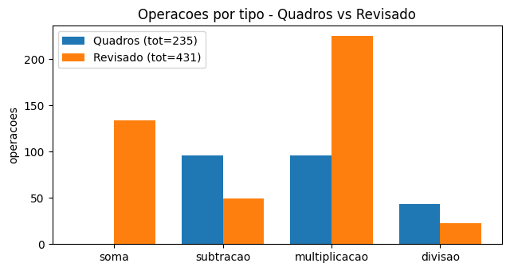

```python
# plot comparativo (operacoes por tipo)
tipos = ['soma', 'subtracao', 'multiplicacao', 'divisao']
x = np.arange(len(tipos)); w = 0.38
fig, ax = plt.subplots(figsize=(6.5, 3.5))
ax.bar(x - w/2, [rt.counter.as_dict()[t] for t in tipos], w, label=f'Quadros (tot={rt.counter.total()})')
ax.bar(x + w/2, [rr.counter.as_dict()[t] for t in tipos], w, label=f'Revisado (tot={rr.counter.total()})')
ax.set_xticks(x); ax.set_xticklabels(tipos); ax.set_ylabel('operacoes')
ax.set_title('Operacoes por tipo - Quadros vs Revisado')
ax.legend(); plt.tight_layout(); plt.show()
```

**Conclusao.** Em contagem **densa** o Simplex Revisado faz *mais* operacoes (overhead de $B^{-1}$, $y$, $d$ e repricing por iteracao): aqui **235 (Quadros)** vs **431 (Revisado)**. Custo total $\sim O(m^2 n)$ nos dois (mesmo termo dominante). A vantagem do Revisado e **estrutural**: memoria $O(m^2)$ vs $O(mn)$, esparsidade e estabilidade compensa quando $n \gg m$ e $A$ e esparsa; o Quadros e melhor para problemas pequenos e densos.

# Exercicio 4 - Pseudocodigo e Fluxograma (Simplex Revisado)

**Pseudocodigo (duas fases, $B^{-1}$ explicita):**

1. Padronizar (folga/excesso/artificial); $B^{-1}=I$; base inicial.
2. **Fase 1** (se ha artificiais): max $-\sum a_i$. Se $\sum a_i>0 \Rightarrow$ **INFACTIVEL**.
3. **Fase 2** — repetir:
   - $x_B = B^{-1}b$ ; $y = c_B B^{-1}$
   - custos reduzidos $r_j = y A_j - c_j$ (nao-basicas)
   - se todo $r_j \ge 0 \Rightarrow$ **OTIMO** (UNICA se todos $>0$; MULTIPLA se algum $=0$)
   - senao entra $q=\arg\min_j r_j$
   - direcao $d = B^{-1}A_q$ ; se $d \le 0 \Rightarrow$ **ILIMITADA**
   - razao minima $t^*=\min_{d_i>0}(x_B)_i/d_i \Rightarrow$ sai $r$
   - atualiza $B^{-1} \leftarrow E B^{-1}$ (matriz eta) ; $base[r]=q$

Fluxograma (gerado pelo codigo abaixo):

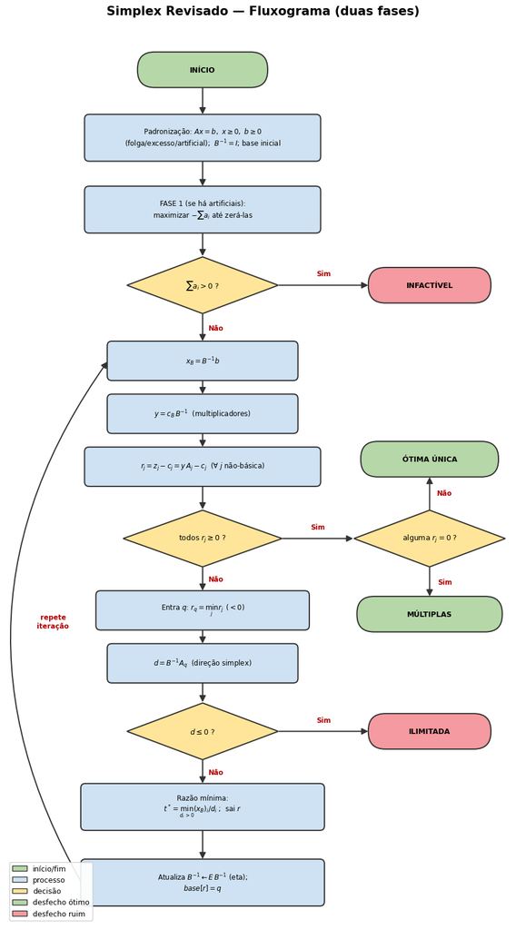

```python
import os
from dataclasses import dataclass
from typing import Tuple

import matplotlib.pyplot as plt
from matplotlib.patches import FancyArrowPatch, FancyBboxPatch, Polygon


# Paleta
C_PROC = "#cfe2f3"   # processo (azul claro)
C_DEC = "#ffe599"    # decisão (amarelo)
C_START = "#b6d7a8"  # início (verde)
C_GOOD = "#b6d7a8"   # desfecho ótimo (verde)
C_BAD = "#f49aa0"    # desfecho ruim (vermelho claro)
EDGE = "#333333"


@dataclass
class Node:
    x: float
    y: float
    w: float
    h: float
    kind: str          # 'proc' | 'dec' | 'term'
    text: str
    fc: str = C_PROC

    def top(self) -> Tuple[float, float]:
        return (self.x, self.y + self.h / 2)

    def bottom(self) -> Tuple[float, float]:
        return (self.x, self.y - self.h / 2)

    def left(self) -> Tuple[float, float]:
        return (self.x - self.w / 2, self.y)

    def right(self) -> Tuple[float, float]:
        return (self.x + self.w / 2, self.y)


def draw_node(ax, n: Node) -> None:
    if n.kind == "dec":
        poly = Polygon(
            [(n.x, n.y + n.h / 2), (n.x + n.w / 2, n.y),
             (n.x, n.y - n.h / 2), (n.x - n.w / 2, n.y)],
            closed=True, facecolor=n.fc, edgecolor=EDGE, lw=1.5, zorder=2)
        ax.add_patch(poly)
        fs = 9
    else:
        rounding = 0.45 if n.kind == "term" else 0.12
        box = FancyBboxPatch(
            (n.x - n.w / 2, n.y - n.h / 2), n.w, n.h,
            boxstyle=f"round,pad=0.02,rounding_size={rounding}",
            facecolor=n.fc, edgecolor=EDGE, lw=1.5, zorder=2)
        ax.add_patch(box)
        fs = 9 if n.kind == "term" else 8.5
    weight = "bold" if n.kind == "term" else "normal"
    ax.text(n.x, n.y, n.text, ha="center", va="center", fontsize=fs,
            zorder=3, fontweight=weight)


def arrow(ax, p1, p2, label: str = "", rad: float = 0.0,
          label_dx: float = 0.0, label_dy: float = 0.0) -> None:
    ax.add_patch(FancyArrowPatch(
        p1, p2, arrowstyle="-|>", mutation_scale=16, lw=1.5, color=EDGE,
        connectionstyle=f"arc3,rad={rad}", zorder=1, shrinkA=1, shrinkB=1))
    if label:
        mx, my = (p1[0] + p2[0]) / 2 + label_dx, (p1[1] + p2[1]) / 2 + label_dy
        ax.text(mx, my, label, ha="center", va="center", fontsize=8.5,
                fontweight="bold", color="#b00000",
                bbox=dict(boxstyle="round,pad=0.1", fc="white", ec="none"),
                zorder=4)


def build() -> None:
    fig, ax = plt.subplots(figsize=(13, 16))

    # ---- Nós (spine central x=0; desfechos à direita x=5.9) ----
    start = Node(0, 23.0, 3.4, 0.9, "term", "INÍCIO", C_START)
    n1 = Node(0, 21.2, 6.2, 1.2, "proc",
              "Padronização: $Ax=b,\\ x\\geq0,\\ b\\geq0$\n"
              "(folga/excesso/artificial);  $B^{-1}=I$; base inicial")
    n2 = Node(0, 19.3, 6.2, 1.2, "proc",
              "FASE 1 (se há artificiais):\nmaximizar $-\\sum a_i$ até zerá-las")
    d0 = Node(0, 17.3, 4.0, 1.5, "dec", "$\\sum a_i > 0$ ?", C_DEC)
    t_inf = Node(6.0, 17.3, 3.2, 0.9, "term", "INFACTÍVEL", C_BAD)

    n3 = Node(0, 15.3, 5.0, 1.0, "proc", "$x_B = B^{-1} b$")
    n4 = Node(0, 13.9, 5.0, 1.0, "proc", "$y = c_B\\, B^{-1}$  (multiplicadores)")
    n5 = Node(0, 12.5, 6.2, 1.0, "proc",
              "$r_j = z_j - c_j = y\\,A_j - c_j$  (∀ $j$ não-básica)")
    d1 = Node(0, 10.6, 4.2, 1.5, "dec", "todos $r_j \\geq 0$ ?", C_DEC)

    d2 = Node(6.0, 10.6, 4.0, 1.5, "dec", "alguma $r_j = 0$ ?", C_DEC)
    t_uni = Node(6.0, 12.7, 3.6, 0.9, "term", "ÓTIMA ÚNICA", C_GOOD)
    t_mul = Node(6.0, 8.6, 3.8, 0.9, "term", "MÚLTIPLAS", C_GOOD)

    n6 = Node(0, 8.7, 5.6, 1.0, "proc", "Entra $q$: $r_q = \\min_j r_j\\ (<0)$")
    n7 = Node(0, 7.3, 5.0, 1.0, "proc", "$d = B^{-1} A_q$  (direção simplex)")
    d3 = Node(0, 5.5, 4.0, 1.5, "dec", "$d \\leq 0$ ?", C_DEC)
    t_ili = Node(6.0, 5.5, 3.2, 0.9, "term", "ILIMITADA", C_BAD)

    n8 = Node(0, 3.5, 6.4, 1.2, "proc",
              "Razão mínima:\n$t^* = \\min_{d_i>0} (x_B)_i / d_i$ ;  sai $r$")
    n9 = Node(0, 1.5, 6.4, 1.2, "proc",
              "Atualiza $B^{-1} \\leftarrow E\\,B^{-1}$ (eta);\n$base[r] = q$")

    nodes = [start, n1, n2, d0, t_inf, n3, n4, n5, d1, d2, t_uni, t_mul,
             n6, n7, d3, t_ili, n8, n9]
    for nd in nodes:
        draw_node(ax, nd)

    # ---- Setas ----
    arrow(ax, start.bottom(), n1.top())
    arrow(ax, n1.bottom(), n2.top())
    arrow(ax, n2.bottom(), d0.top())
    arrow(ax, d0.bottom(), n3.top(), "Não", label_dx=0.35)
    arrow(ax, d0.right(), t_inf.left(), "Sim", label_dy=0.3)

    arrow(ax, n3.bottom(), n4.top())
    arrow(ax, n4.bottom(), n5.top())
    arrow(ax, n5.bottom(), d1.top())
    arrow(ax, d1.bottom(), n6.top(), "Não", label_dx=0.35)
    arrow(ax, d1.right(), d2.left(), "Sim", label_dy=0.3)
    arrow(ax, d2.top(), t_uni.bottom(), "Não", label_dx=0.4)
    arrow(ax, d2.bottom(), t_mul.top(), "Sim", label_dx=0.4)

    arrow(ax, n6.bottom(), n7.top())
    arrow(ax, n7.bottom(), d3.top())
    arrow(ax, d3.bottom(), n8.top(), "Não", label_dx=0.35)
    arrow(ax, d3.right(), t_ili.left(), "Sim", label_dy=0.3)
    arrow(ax, n8.bottom(), n9.top())

    # Loop de volta: n9 -> n3 (lado esquerdo, arco para fora)
    arrow(ax, n9.left(), n3.left(), "repete\niteração", rad=-0.32,
          label_dx=-1.1)

    # ---- Legenda ----
    handles = [
        FancyBboxPatch((0, 0), 1, 1, boxstyle="round", fc=C_START, ec=EDGE),
        FancyBboxPatch((0, 0), 1, 1, boxstyle="round", fc=C_PROC, ec=EDGE),
        Polygon([(0, 0)], fc=C_DEC, ec=EDGE),
        FancyBboxPatch((0, 0), 1, 1, boxstyle="round", fc=C_GOOD, ec=EDGE),
        FancyBboxPatch((0, 0), 1, 1, boxstyle="round", fc=C_BAD, ec=EDGE),
    ]
    ax.legend(handles, ["início/fim", "processo", "decisão",
                        "desfecho ótimo", "desfecho ruim"],
              loc="lower left", fontsize=9, framealpha=0.9)

    ax.set_title("Simplex Revisado — Fluxograma (duas fases)",
                 fontsize=15, fontweight="bold", pad=12)
    ax.set_xlim(-5.2, 8.4)
    ax.set_ylim(0.4, 24.2)
    ax.set_aspect("equal")
    ax.axis("off")
    fig.tight_layout()

build()
```